# Diagnose fehlender Werte

Autor:in

Zugehörigkeit

Samuel Merk

Pädagogische Hochschule Karlsruhe

# 1 Die Verteilung fehlender Werte

## 1.1 Unterscheidung nach Schafer & Graham (2002)

Zur Beschriebung der Verteilung fehlender Werte in zweidimensionalen Daten kann zunächst eine Unterscheidung zwischen univariaten, monotonen und arbiträren Mustern (siehe Abbildung 1) getroffen werden (Schafer & Graham, 2002).

[figure not shown]

Abbildung 1: Missing Data Patterns nach Schafer und Graham (2002). Links eine univariate, in der Mitte eine monotone und rechts eine arbiträre Verteilung.

## 1.2 Diagnostik der Verteilung fehlender Werte

Univariate, monotone und arbiträre Verteilungen fehlender Werte werden meistens mit Visualisierungen diagnostiziert. Hierzu gibt es verschiedene Möglichkeiten, z.B. die Visualisierung von fehlenden Werten in einem Datensatz mit den Funktionen

- `naniar::vis_miss()`
- `naniar::gg_miss_upset()`
- `Amelia::missmap()`
- `ggmice::plot_pattern()`

### 1.2.1 Beispiel: Monotone Verteilung fehlender Werte

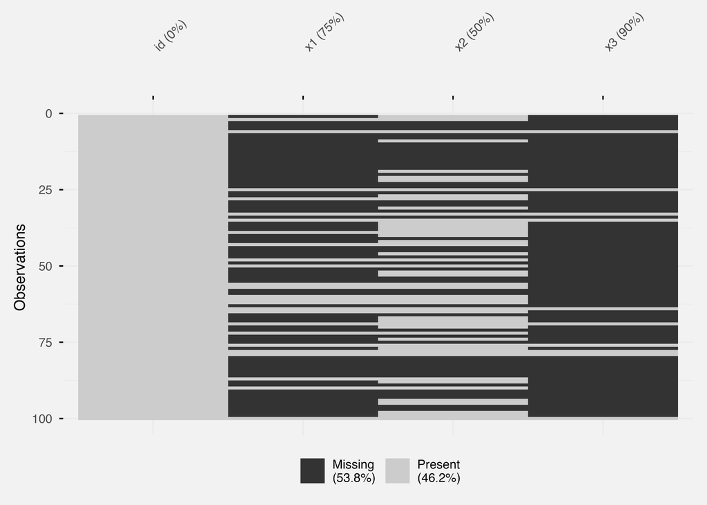

Abbildung 2

```r
library(tibble)
library(naniar)
library(dplyr)
library(ggplot2)
library(brand.yml)
data_monotonemissing <-
  tibble(
    id = 1:100,
    x1 = c(rnorm(25), rep(NA, 75)),
    x2 = c(rnorm(50), rep(NA, 50)),
    x3 = c(rnorm(10), rep(NA, 90))
  ) %>%
  sample_frac(1) # shuffle rows
vis_miss(data_monotonemissing) +
  theme(plot.margin = margin(t = 20, r = 10, b = 10, l = 10)) +
  theme_brand_ggplot2()
```

Hier wird vielleicht nicht auf den ersten Blick deutlich, dass es sich um eine monotone Verteilung handelt, da die fehlenden Werte nicht von links nach rechts zunehmen. Die `vis_miss()`-Funktion hat aber eine `sort_miss`- und `cluster`-Option, die die fehlenden Werte sortiert und damit die monotone Verteilung deutlich macht:

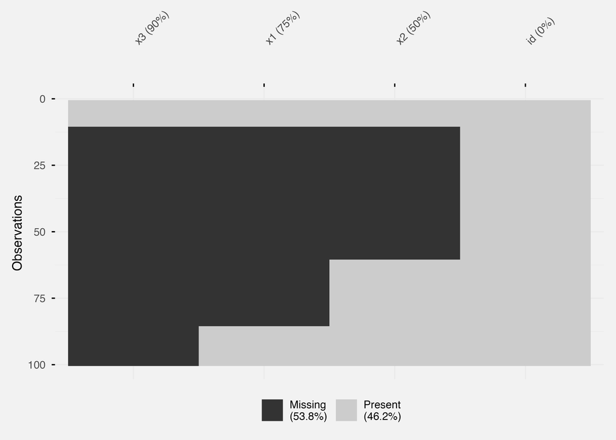

```r
vis_miss(data_monotonemissing, sort_miss = TRUE, cluster = TRUE) +
    theme(plot.margin = margin(t = 20, r = 10, b = 10, l = 10)) +
    theme_brand_ggplot2()
```

## 1.3 Übung: Missing Verteilung

# 2 Diagnose der Missingness Mechanismen

## 2.1 Missing at Random

## 2.2 Missing not at Random

## Literatur

Schafer, J. L., & Graham, J. W. (2002). [Missing data: Our view of the state of the art](https://doi.org/10.1037/1082-989X.7.2.147). *Psychological Methods*, *7*(2), 147–177.